# LOSOM - Iteration 2 Plan Eval (Pre-Iteration 2 Modeling)

Site Update 2021-05-17

## The Data

The data presented here is a subset of the 27k Pareto runs (file: *LOSOM_CPA_PARETO_27k_2020Nov10.xlsx*) produced to select potential plans for the LOSOM effort.

The data contains the RSM-BN input parameters, output performance measures, and describes methods used to select the best performing simulation(s). The original worksheet was produced in the fall of 202 by the SFWMD H&H Modeling Section and the Interagency Modeling Center, as directed by the USACE for the LOSOM project.

- Team: Pattie Fulton, Walter Wilcox, Cal Neidrauer, Alaa Ali, Raul Novoa, Randy VanZee, Hal Correa, Sashi Nair, Jenifer Barnes, Maliha Ahmed, Danielle Morancy, Clay Brown, Sandeep Dabral

## Iteration 2 - Balanced Plans

The selected plans to move forward to Iteration 2 modeling are based on either plans within the initial Pareto evaluation (i.e. conceptual plans) or plans evaluated during Iteration 1 modeling with modifications. Therefore the plans of the balanced array with the proposed modifications will make them significantly different than the initial plans presented below. Below are the origins and proposed modifications for each plan within the balanced array.

**Plan AA**

- Original framework is based on Iteration 1 Plan ESLE (Model Index: 4C-1_3307) with the following modifications:
  - Reduce S308 flows to St. Lucie Estuary,
  - Improve water supply performance,
  - Improve performance for algal blooms in estuaries,
  - Consider C43 high flows and high Lake metrics.

**Plan BB**

- Original framework is based on Iteration 1 Plan SPLC with the the following modifications:
  - Reduce low and high flows to CRE,
  - Improve flows south,
  - Reduce flows to SLE through S-308,
  - Consider high lake metrics, flows south during dry times, and meeting CRE low flows.

**Plan CC**

- Original framework is based on Pareto Plan D (Balanced Plan Workshop April 2021) with the the following modifications:
  - Reduce Caloosahatchee Estuary >6500 cfs,
  - Improve St. Lucie Estuary high flow event counts,
  - Improve water supply performance,
  - Consider high lake metrics.

**Plan DD**

- Original framework is based on Pareto Plan A (Balanced Plan Workshop April 2021) with the the following modifications:
  - Improve Caloosahatchee Estuary optimal flows and high flows,
  - Investigate incremental improvement across all objectives,
  - Consider high lake stage metrics.

**Plan EE**

- Plan is new and intended for operational flexibility.

Metrics specific to Caloosahatchee River Estuary (CRE), Regulatory discharges (to CRE and St Lucie Estuary), Lake Okeechobee Stage envelope and flow south.

| Pareto Plan ID | Model_Index | CRE < 457 cfs (PM48) | CRE 457-750 cfs (PM49) | CRE 750-2100 cfs (PM51) | CRE 2100-2600 cfs (PM14) | CRE 2600-4500 cfs (PM52) | CRE 4500-6500 cfs (PM53) | CRE >6500 cfs (PM54) | CRE MFL Exceed (PM55) | S77 Reg Flow (PM56) | S380 Reg Flow (PM61) | Lake Okeechobee Lower Stg Env Pen (PM12) | Lake Okeechobee Upper Stg Env Pen (PM13) | Flow South (PM46) |
| --- | --- | --- | --- | --- | --- | --- | --- | --- | --- | --- | --- | --- | --- | --- |
| --- | LSMECB | 548 | 280 | 465 | 346 | 355 | 113 | 60 | 36 | 515 | 220 | 17860 | 13525 | 57 |
| --- | LSM25B | 77 | 516 | 600 | 292 | 264 | 91 | 51 | 12 | 477 | 238 | 18717 | 12160 | 56 |
| AA | 4C-1_3307 | 55 | 236 | 729 | 296 | 355 | 136 | 56 | 7 | 688 | 11 | 20922 | 12607 | 135 |
| BB1 | --- | --- | --- | --- | --- | --- | --- | --- | --- | --- | --- | --- | --- | --- |
| CC | 4C-1_1655 | 71 | 316 | 794 | 254 | 227 | 81 | 65 | 10 | 542 | 59 | 14565 | 22922 | 163 |
| DD | 4C-3_3840 | 71 | 515 | 584 | 213 | 291 | 169 | 57 | 9 | 508 | 187 | 17118 | 9905 | 90 |

WARNING: Balanced plans based on plans with modifications. Modification to plans not reflected in this data.  
1Based on stakeholder plan SPLC, no Pareto information available

Water Supply Specific Metric.

| Pareto Plan ID | Model_Index | Water Supply SEM BCYP not met (PM6) | Water Supply SEM BR not met (PM7) | Water Supply LOSA Cutback (PM8) | Water Supply LOSA 4in1 (PM9) | Water Supply LOSA Rec (PM10) |
| --- | --- | --- | --- | --- | --- | --- |
| --- | LSMECB | 3 | 5 | 26 | 8 | 25 |
| --- | LSM25B | 3 | 5 | 26 | 8 | 25 |
| AA | 4C-1_3307 | 3 | 5 | 27 | 10 | 30 |
| BB1 | --- | --- | --- | --- | --- | --- |
| CC | 4C-1_1655 | 2 | 4 | 22 | 7 | 21 |
| DD | 4C-3_3840 | 2 | 4 | 24 | 7 | 24 |

WARNING: Balanced plans based on plans with modifications. Modification to plans not reflected in this data.  
1Based on stakeholder plan SPLC, no Pareto information available

Percent difference relative to FWO (LSM25B) for selected performance measures.

| PlanName | Model_Index | PM48 | PM49 | PM51 | PM14 | PM52 | PM53 | PM54 | PM55 | PM56 | PM61 | PM12 | PM13 | PM46 | PM6 | PM7 | PM8 | PM9 | PM10 |
| --- | --- | --- | --- | --- | --- | --- | --- | --- | --- | --- | --- | --- | --- | --- | --- | --- | --- | --- | --- |
| --- | LSMECB | --- | --- | --- | --- | --- | --- | --- | --- | --- | --- | --- | --- | --- | --- | --- | --- | --- | --- |
| --- | LSM25B | 0 | 0 | 0 | 0 | 0 | 0 | 0 | 0 | 0 | 0 | 0 | 0 | 0 | 0 | 0 | 0 | 0 | 0 |
| AA | 4C-1_3307 | -29 | -54 | 22 | 1 | 34 | 49 | 10 | -42 | 44 | -95 | 12 | 4 | 140 | 12 | 12 | 4 | 15 | 20 |
| BB1 | --- | --- | --- | --- | --- | --- | --- | --- | --- | --- | --- | --- | --- | --- | --- | --- | --- | --- | --- |
| CC | 4C-1_1655 | -8 | -39 | 32 | -13 | -14 | -11 | 27 | -17 | 14 | -75 | -22 | 88 | 188 | -14 | -22 | -16 | -20 | -16 |
| DD | 4C-3_3840 | -8 | -0 | -3 | -27 | 10 | 86 | 12 | -25 | 7 | -21 | -9 | -19 | 59 | -8 | -12 | -9 | -10 | -4 |

WARNING: Balanced plans based on plans with modifications. Modification to plans not reflected in this data.  
1Based on stakeholder plan SPLC, no Pareto information available

### Multi Criteria Decision Analysis

- Multi-Criteria Decision Analysis (MCDA) presented by USACE PDT to evaluate iteration 1 plans.
- Methodology to synthesize sub-objective performance for each alternative based on key performance metrics identified by sub-teams.
- Used here to evaluate the selected plans and only focuses on Caloosahatchee Estuary, Lake Okeechobee, South Florida Ecology and St Lucie Estuary metrics as presented by USACE (12-April 2021 - PDT workshop).

| Lake Okeechobee Key Metric. PM | Lake Okeechobee Key Metric. Metric | Lake Okeechobee Key Metric. Weight |
| --- | --- | --- |
| 13 | Upper Lake Stage penalties | 30 |
| 45 | Lake MFL Exccedances | 30 |
| 43 | % of time lake stage >17Ft | 30 |
| 39 | % within lake stage envelope | 10 |

| Caloosahatchee Estuary Metric. PM | Caloosahatchee Estuary Metric. Metric | Caloosahatchee Estuary Metric. Weight |
| --- | --- | --- |
| 48 | ≤ 457 cfs | 25 |
| 54 | ≥ 6500 cfs | 25 |
| 51 | RECOVER Optimal Events | 20 |
| 53 | 4500 - 6500 cfs | 20 |
| 52 | 2600 - 4500 cfs | 10 |

| St Lucie Estuary Metric. PM | St Lucie Estuary Metric. Metric | St Lucie Estuary Metric. Weight |
| --- | --- | --- |
| 61 | S308 Flows | 50 |
| 60 | Damaging Flow Event counts triggered from LOK | 30 |
| 17 | High Flow Event counts triggered from LOK | 20 |

| South Florida Metric. PM | South Florida Metric. Metric | South Florida Metric. Weight |
| --- | --- | --- |
| 46 1 | Average annual flow south | 50 |
| 47 | Average annual STA 2 and 3/4 outflow | 50 |

1 Slighly different than originall presented by USACE. Wet and Dry season discharges are not seggregated for flows south in Pareto evaluation.

MCDA Score for selected plans specific to environmental/ecological considerations of Lake Okeechobee, the estuaries and south Florida.

| PlanName | Model_Index | MCDA Score Lake Okeechobee | MCDA Score Caloosahatchee Estuary | MCDA Score St Lucie Estuary | MCDA Score South Florida |
| --- | --- | --- | --- | --- | --- |
| AA | 4C-1_3307 | 0.5 | 0.9 | 1.0 | 0.9 |
| BB1 | --- | --- | --- | --- | --- |
| CC | 4C-1_1655 | 0.3 | 1.0 | 0.7 | 1.0 |
| DD | 4C-3_3840 | 1.0 | 0.6 | 0.0 | 0.6 |

WARNING: Balanced plans based on plans with modifications. Modification to plans not reflected in this data.  
1Based on stakeholder plan SPLC, no Pareto information available

### Performance Measure Definitions

Performance measures used in the analysis above with definitions and abbreviations.

| PM | Abbreviation | Units | Description |
| --- | --- | --- | --- |
| PM6 | SEM_BCYP_notmet | Percent | STOF - Big Cypress Reservation percentage of demand not met. |
| PM7 | SEM_BR_notmet | Percent | STOF - Brighton Reservation percentage of demand not met. |
| PM8 | LOSA_cutback_wt_avg | Percent | Weighted average of LOSA demand cutback volumes to supplemental demand volumes (1973-1974, 1981-1982, 2001, 2007-2008, 2011) . |
| PM9 | LOSA_4in1_dmd_notmet_EAA_non-EAA | Percent | Weighted average of LOSA supplemental irrigation demand not met for EAA and non-EAA areas (298 Districts, S4, L8, C43, N Lakeshore, NE Lakeshore and Lower Istokpoga. |
| PM10 | LOSA_REC_duration | Count | The number of months months when significant cutbacks in water use due to declared water shortages are being simulated. |
| PM12 | LOK_stgenv_lower_penalty | Score | Count of weighted exceedances (penalty) below LOK stage envelope. Criteria based on previous year's stage to trigger shifting envelopes on 1-Jan each year. |
| PM13 | LOK_stgenv_upper_penalty | Score | Count of weighted exceedances (penalty) above LOK stage envelope. Criteria based on previous year's stage to trigger shifting envelopes on 1-Jan each year. |
| PM14 | CAE_High | Count | Number of times 14-day moving average >= 2100 cfs and < 2600 cfs. |
| PM46 | LOK_flow_south | k-ac-ft/yr | Average annual flow for POR (S351, S354). |
| PM48 | CAE_<457 | Counts | Number of times 14-day moving average < 457 cfs. |
| PM49 | CAE_457_750 | Counts | Number of times 14-day moving average >= 457 and < 750 cfs. |
| PM51 | CAE_Optimal | Counts | Number of times 14-day moving average >= 750 and < 2100 cfs. |
| PM52 | CAE_2600_4500 | Counts | Number of times 14-day moving average >= 2600 and < 4500 cfs. |
| PM53 | CAE_4500_6500 | Counts | Number of times 14-day moving average >= 4500 and < 6500 cfs. |
| PM54 | CAE_>6500 | Counts | Number of times 14-day moving average >= 6500 cfs. |
| PM55 | CAE_MFL_Exceedances | Counts | Numer of exceedances Caloosahatchee MFL criteria during simulated POR. Exceedance Criteria: 30 day average flow below MFL criteria is less than 457 (cfs). |
| PM56 | S77_reg_flow | k-ac-ft/yr | Average annual flow for S77 regulatory flow discharge. |
| PM61 | S308_reg_flow | k-ac-ft/yr | Average annual flow for S308 regulatory flow discharge. |

## Relative Difference from FWO and ECB

### Estuaries

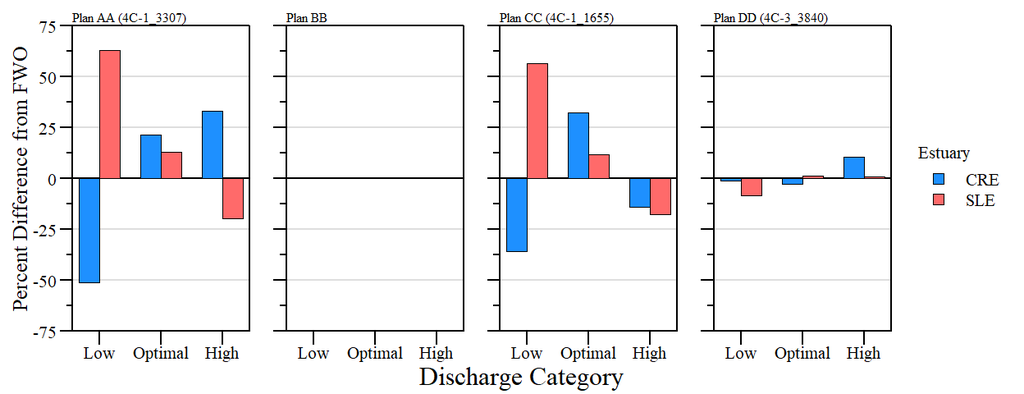

Percent Difference from FWO (LSM25B) for low, optimal and high dicharges for Caloosahatchee River Estuary and St Lucie Estuary (CRE and SLE, respectively).

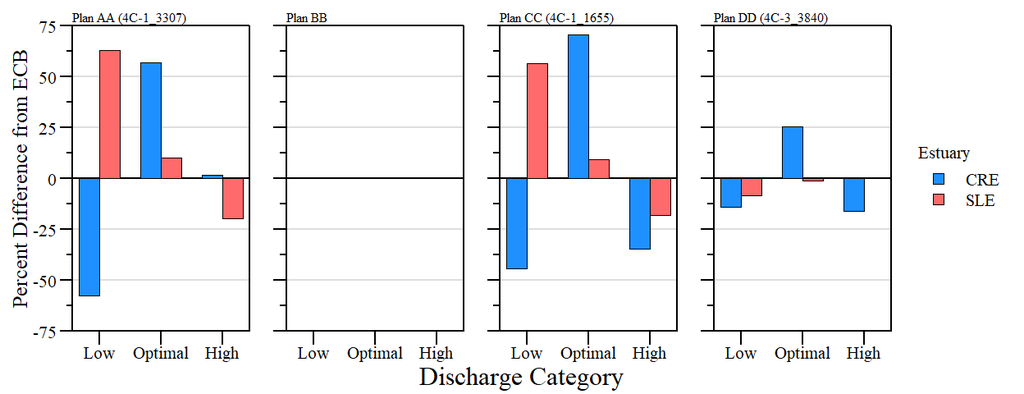

Percent Difference from ECB (LSMECB) for low, optimal and high dicharges for Caloosahatchee River Estuary and St Lucie Estuary (CRE and SLE, respectively).

### Lake Okeechobee

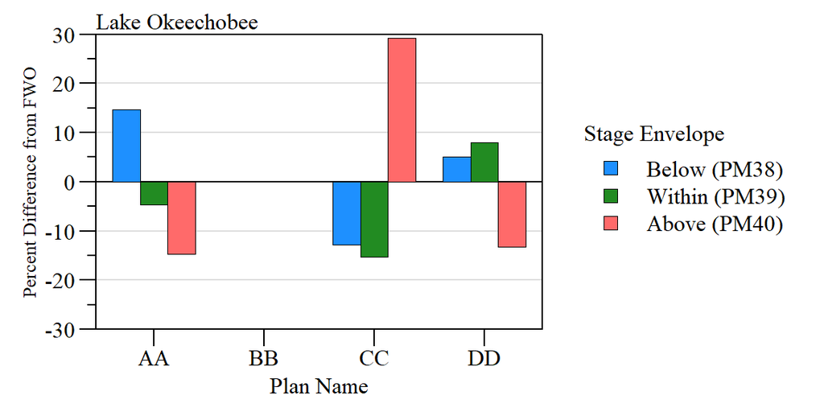

Percent Difference from FWO (LSM25B) for below, within and above the Lake Okeechobee Stage Envelope.

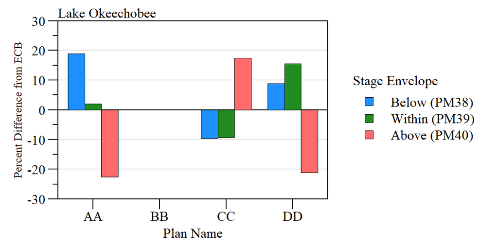

Percent Difference from ECB (LSMECB) for below, within and above the Lake Okeechobee Stage Envelope.

### Flow South

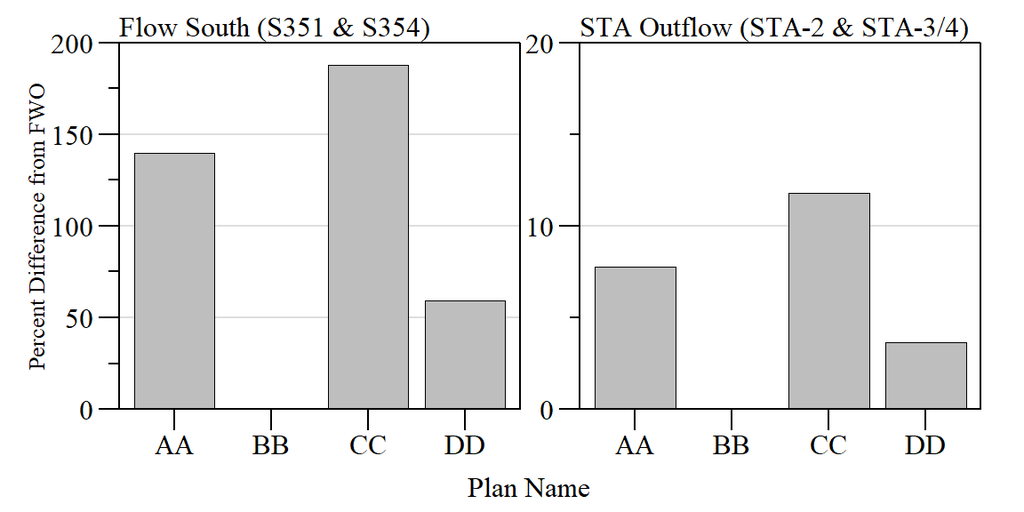

Percent Difference from FWO (LSM25B) Discharges south (S351, S354) and STA outflow (STA-2 & STA-3/4).

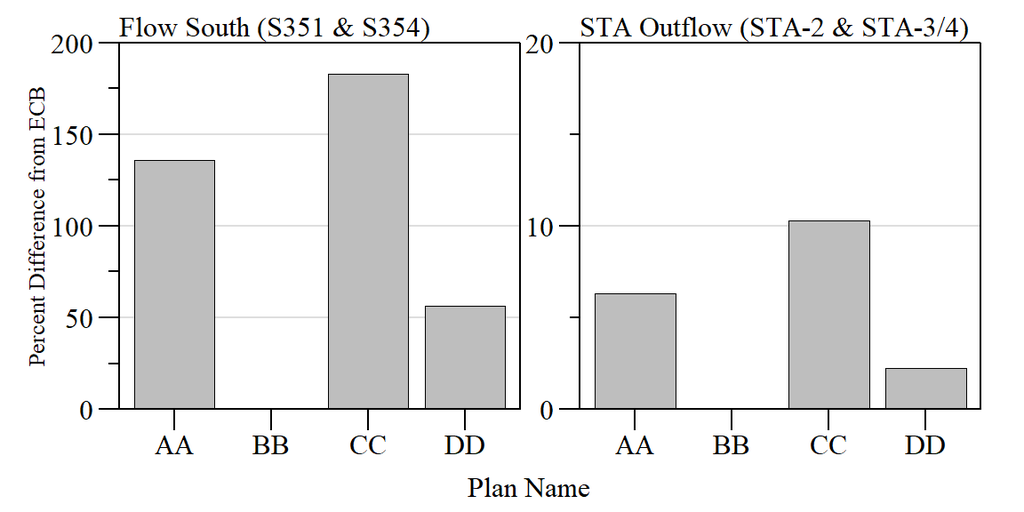

Percent Difference from ECB (LSMECB) Discharges south (S351, S354) and STA outflow (STA-2 & STA-3/4).